# ABS Strike Zone Comparison EDA

Charlie Braverman, Beili Chou, Andrew Hack

2025-03-07

## Introduction

Major League Baseball continues embracing technology by implementing an automated ball-strike (ABS) challenge system in spring training this year. While it will not be used in 2025, this system could be implemented in real games as soon as next year.. With a robotic strike zone, the league has changed its definition of the strike zone’s height to be 27% to 53.5% of a batter’s height. This marks a departure from the old rule from the midpoint between the shoulders and the top of the uniform pants to the top of the knees. While the 2025 season’s strike zone may be less impacted because human umpires will still be responsible for calling balls and strikes, the new strike zone may impact different players to different degrees. A key question for players, managers, and MLB front offices arises: which players stand to benefit from this change, and who might suffer?

The most obvious factor to investigate first is height. A taller player could see their effective strike zone shift more dramatically than a shorter counterpart. However, other elements, such as batting stance or body proportions, may also influence hitter and pitcher outcomes. By analyzing historical pitch-tracking data from Statcast, we will try to predict how the new strike zone rules will affect both hitters and pitchers.

## Conventions

with_underscores

Variables: nouns

Functions: verbs

Automated ball-strike challenge system -> ABS

Major League Baseball -> MLB

Weighted On-Base Average -> wOBA

### IMPORTANT: While developing this research, code will be tested on sample data. Github does not appreciate the 500MB file of pitch data that is generated by scraping a full season of MLB. The data in “data/full_pitch_df.csv” is only 50,000 rows of data from the middle of the season. The final analysis will be run on the full data set. Please do not write a full season to “data/full_pitch_df.csv” or you will face errors when pushing. While this notice is present, all findings are only relevant to the sample data. Once the code is complete, this notice will be removed, and the final analysis will be written based on the findings from the full data set.

## Packages & Functions

Uncommon Packages: baseballr Petti and Gilani (n.d.)

baseballr is a package written for R focused on baseball analysis. It includes functions for scraping various data from websites, such as FanGraphs.com, Baseball-Reference.com, and baseballsavant.mlb.com. It also includes functions for calculating metrics, such as wOBA, FIP, and team-level consistency over custom time frames.

You can read more about some of the functions and how to use them at its official site, http://billpetti.github.io/baseballr/index.html.

Sourced Functions: scrape_statcast() https://jacobrichey.github.io/2020-06-06-Build-a-Statcast-Database-in-R/

The scrape_statcast() function is a custom function that scrapes pitch-by-pitch data from Statcast for a given season. It takes a season as an argument and returns a data frame with all the pitch-by-pitch data for that season. The function uses the baseballr package to scrape the data from baseballsavant.mlb.com. This is necessary since baseballr scraping functions only return up to 25000 rows of data, and we need to scrape all the data for a season.

```r
library(tidyverse)
library(baseballr)
```

```r
# scrape data from Statcast and write to csv
scrape_statcast <- function(season) {

  # create weeks of dates for season from mar - nov
  # includes spring training + postseason
  dates <- seq.Date(as.Date(paste0(season, '-03-25')),
                    as.Date(paste0(season, '-11-15')), by = 'week')

  date_grid <- tibble(start_date = dates,
                      end_date = dates + 6)

  # create 'safe' version of scrape_statcast_savant in case week doesn't process
  safe_savant <- safely(scrape_statcast_savant_pitcher_all)

  # loop over each row of date_grid, and collect each week in a df
  payload <- map(.x = seq_along(date_grid$start_date),
                 ~{message(paste0('\nScraping week of ', date_grid$start_date[.x], '...\n'))

                   payload <- safe_savant(start_date = date_grid$start_date[.x],
                                          end_date = date_grid$end_date[.x])

                   return(payload)
                 })

  payload_df <- map(payload, 'result')

  # eliminate results with an empty dataframe
  number_rows <- map_df(.x = seq_along(payload_df),
                        ~{number_rows <- tibble(week = .x,
                                                number_rows = length(payload_df[[.x]]$game_date))}) %>%
    filter(number_rows > 0) %>%
    pull(week)

  payload_df_reduced <- payload_df[number_rows]

  combined <- payload_df_reduced %>%
    bind_rows()

  return(combined)
}
```

## Data

Statcast provides pitch-by-pitch data for every game played in MLB. Our approach will be to pull pitch data and join with another data set that holds: batter_id, batter_name, and batter_height. This full data set will allow for us to sort by batter produce the new rulebook strike zone for each.

Further documentation on variable names and their meanings can be found here: https://baseballsavant.mlb.com/csv-docs

Biofile data is obtained from https://www.retrosheet.org/biofile.htm, specifically the biofile0 since it contains heights in inches.

One assumption that must be made is that batting stance will not affect the strike zone. This is a simplification that will be made for the sake of this analysis. In the future, maybe Statcast data will be used to record batting stance height, and this assumption can be revisited.

```r
# ONLY RUN THIS IF SCRAPING A FULL SEASON AND NOT JUST USING SAMPLE DATA
# tracking time for optimizing code efficiency
# If scraping a season, this chunk should take about 25-30 minutes to run (oof).
t <- Sys.time()

# scrape data from Statcast for 2024 season (Only run if data is not present in data file, or if you need to download another season.)
full_pitch_df <- scrape_statcast(season = 2024)


player_id_key_df <- chadwick_player_lu()

player_id_key_df <- player_id_key_df %>% select(key_mlbam, key_retro, name_last, name_first) %>% filter(!is.na(key_mlbam))

# Perform a join on "batter" in full_pitch_df and "key_mlbam" in player_id_key_df
full_pitch_df <- full_pitch_df %>%
  left_join(player_id_key_df, by = c("batter" = "key_mlbam")) %>%
  # Create the combined name field
  mutate(
    batter_name = paste(name_last, name_first, sep = ", "),
   key_retro   = key_retro
  )



# turn list of key_retro into character
full_pitch_df$key_retro <- as.character(full_pitch_df$key_retro)

# read in biofile data and join with full_pitch_df to get batter height
biofile_df <- read_csv("data/biofile_df.csv") %>% select(id, height)

batter_height_df <- full_pitch_df %>% full_join(biofile_df, by = c("key_retro" = "id")) %>% select(batter, height) %>% distinct()

# join full_pitch_df with batter_height_df to get batter height in pitch data
full_pitch_df <- full_pitch_df %>% left_join(batter_height_df, by = c("batter" = "batter")) %>% rename(batter_height = height)

# remove rows with NA sz_top and sz_bot
full_pitch_df <- full_pitch_df %>% filter(sz_top!="NA", sz_bot!="NA")

# changing sz_bot and top and plate_x/z to inches
full_pitch_df$sz_bot <- full_pitch_df$sz_bot * 12
full_pitch_df$sz_top <- full_pitch_df$sz_top * 12

full_pitch_df$plate_x <- full_pitch_df$plate_x * 12
full_pitch_df$plate_z <- full_pitch_df$plate_z * 12

# calculate new strike zone top and bottom based on batter height
full_pitch_df <- full_pitch_df %>% mutate(abs_sz_bot = .27 * batter_height, abs_sz_top = .535 * batter_height)

# calculate sz height and abs sz height
full_pitch_df <- full_pitch_df %>% mutate(sz_height = sz_top - sz_bot, abs_sz_height = abs_sz_top - abs_sz_bot)

# calculate strike zone area for current and ABS strike zones for all players
full_pitch_df <- full_pitch_df %>% mutate(sz_area = sz_height * 17, abs_sz_area = abs_sz_height * 17)

# Add column "old_sz_biz" and "abs_sz_biz" to full_pitch_df
full_pitch_df <- full_pitch_df %>% mutate(old_sz_biz = ifelse(plate_z > sz_bot & plate_z < sz_top & plate_x > -8.5 & plate_x < 8.5, 1, 0), abs_sz_biz = ifelse(plate_z > abs_sz_bot & plate_z < abs_sz_top & plate_x > -8.5 & plate_x < 8.5, 1, 0))

# create column "batting_team" that if inning_topbot == "Top", then away_team, else home_team
full_pitch_df <- full_pitch_df %>% mutate(batting_team = ifelse(inning_topbot == "Top", away_team, home_team))

# grab first 50,000 rows for sample data
sample_df_for_csv <- full_pitch_df[100000:150000,]
write.csv(sample_df_for_csv, "data/full_pitch_df.csv")

# using sample data for working with the data, full_pitch_df will be used for the final analysis.
#full_pitch_df <- read_csv("data/full_pitch_df.csv")

# Calculate average sz_top and sz_bot
avg_top <- mean(full_pitch_df$sz_top)
avg_bot <- mean(full_pitch_df$sz_bot)

# end time tracking
Sys.time()-t
```

### Overview of Data

Taking a look at pitch location data, which is broken down into x (horizontal) and z (vertical) coordinates:

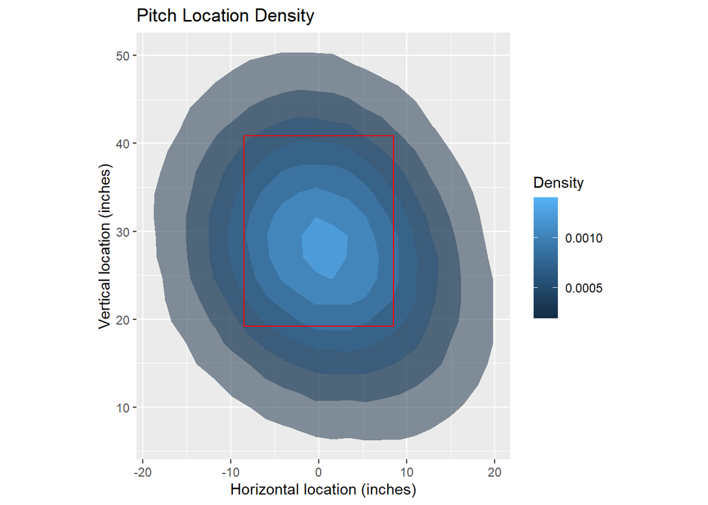

```r
# density plot showing plate_x and plate_z, with the strike zone overlaid, and alpha to show density, with the rectangle just an outline

pitch_loc_plot <- ggplot(full_pitch_df, aes(x = plate_x, y = plate_z)) +
  # Use stat_density2d to compute 2D density; fill is mapped to ..level..
  stat_density2d(
    aes(fill = after_stat(level)),
    geom = "polygon",
    alpha = 0.5
  ) +
  # Rename the legend label for fill
  scale_fill_continuous(name = "Density") +  geom_rect(
    xmin = -8.5, xmax = 8.5,
    ymin = avg_bot, ymax = avg_top,
    fill = NA, color = "red",
    inherit.aes = FALSE
  ) +
  coord_fixed() +
  labs(title = "Pitch Location Density", x = "Horizontal location (inches)", y = "Vertical location (inches)")


pitch_loc_plot
```

```r
# summary statistics for plate_x and plate_z
summary(full_pitch_df$plate_x)
```

```
##     Min.  1st Qu.   Median     Mean  3rd Qu.     Max.
## -64.5600  -6.1200   0.6000   0.6469   7.3200 122.4000
```

```r
summary(full_pitch_df$plate_z)
```

```
##    Min. 1st Qu.  Median    Mean 3rd Qu.    Max.
##  -91.80   20.04   27.72   27.65   35.40  148.32
```

And taking a look at how much the strike zone height varies across different batters:

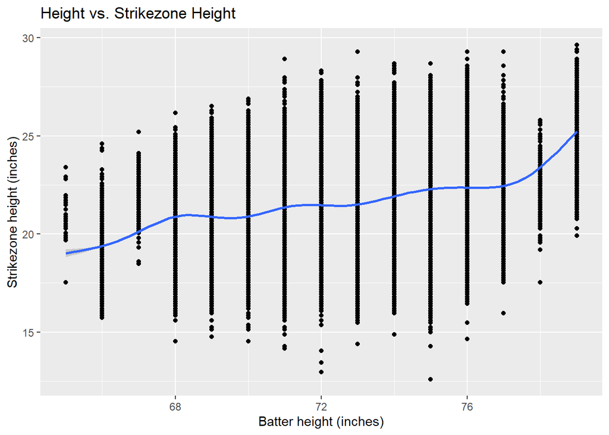

```r
# plot with overlay of average strikezone for every batter height
sz_height_plot <- ggplot(full_pitch_df, aes(x = batter_height, y = sz_height)) +
  geom_point() + geom_smooth(method = "gam") +
  labs(title = "Height vs. Strikezone Height", x = "Batter height (inches)", y = "Strikezone height (inches)")

sz_height_plot
```

```r
# summary statistics for sz_top and sz_bot
summary(full_pitch_df$sz_top)
```

```
##    Min. 1st Qu.  Median    Mean 3rd Qu.    Max.
##   30.36   39.36   40.92   40.89   42.36   51.36
```

```r
summary(full_pitch_df$sz_bot)
```

```
##    Min. 1st Qu.  Median    Mean 3rd Qu.    Max.
##   12.00   18.36   19.20   19.21   20.04   25.68
```

## EDA

Some initial thoughts:

How does the new strike zone compare to the old?

#### Exploring strikezone sizes:

```r
# group by batter height and calculate average strike zone top and bottom
full_pitch_df %>% group_by(batter_height) %>% summarise(avg_abs_sz_top = mean(abs_sz_top), avg_abs_sz_bot = mean(abs_sz_bot), avg_sz_top = mean(sz_top), avg_sz_bot = mean(sz_bot), avg_sz_height_diff = mean(sz_height)-mean(abs_sz_height))
```

```
## # A tibble: 16 × 6
##    batter_height avg_abs_sz_top avg_abs_sz_bot avg_sz_top avg_sz_bot
##            <dbl>          <dbl>          <dbl>      <dbl>      <dbl>
##  1            65           34.8           17.6       36.6       16.9
##  2            66           35.3           17.8       35.5       16.2
##  3            67           35.8           18.1       39.5       17.8
##  4            68           36.4           18.4       38.4       17.8
##  5            69           36.9           18.6       39.3       18.3
##  6            70           37.4           18.9       39.0       18.2
##  7            71           38.0           19.2       40.2       18.8
##  8            72           38.5           19.4       40.4       18.9
##  9            73           39.1           19.7       40.7       19.2
## 10            74           39.6           20.0       41.5       19.5
## 11            75           40.1           20.2       42.0       19.9
## 12            76           40.7           20.5       42.3       19.8
## 13            77           41.2           20.8       43.0       20.6
## 14            78           41.7           21.1       43.0       20.8
## 15            79           42.3           21.3       47.0       21.7
## 16            NA           NA             NA         39.3       18.9
## # ℹ 1 more variable: avg_sz_height_diff <dbl>
```

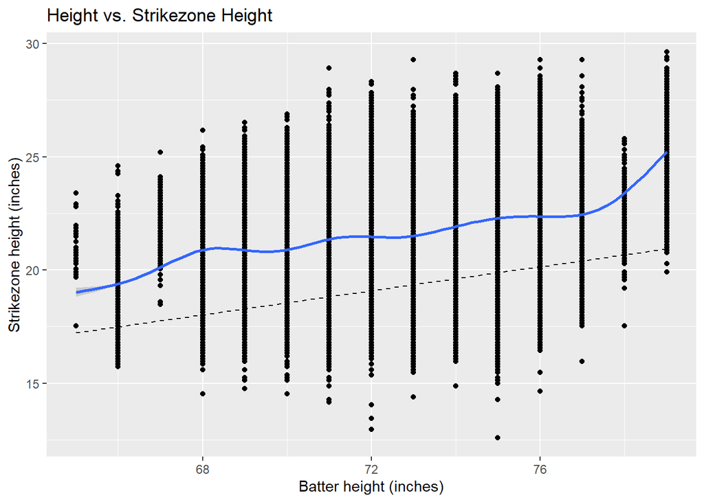

```r
# graph of sz height vs batter_height, with the new strike zone height as a reference line
sz_height_vs_height <- ggplot(full_pitch_df, aes(x = batter_height, y = sz_height)) +
  geom_point() + geom_smooth(method = "gam") + geom_line(aes(x = batter_height, y = abs_sz_height), linetype = "dashed") +
  labs(title = "Height vs. Strikezone Height", x = "Batter height (inches)", y = "Strikezone height (inches)")

sz_height_vs_height
```

The new ABS zone is proportional to batter height, so it acts linearly. One takeaway is that batting stance can explain the deviation in strike zone height for each batter. However, an interesting note is that the ABS strike zone height is significantly smaller than the average current strike zone height at each batter height. Batting stance should theoretically cause current strike zone height to be smaller than ABS strike zone height, but this is not the case. Is the codification of the strike zone going to be a massive change for batters?

Not all batters and pitchers will be affected equally by the new strike zone. Some batters may benefit from the new strike zone, while others may suffer. We can calculate the difference in strike zone area between the current and ABS strike zones to see how much each batter’s strike zone will change. We can also calculate the batting average on balls in zone (BABIZ) for each batter in the current and ABS strike zones to see how their performance might change. Obviously, players may change their approach to hitting based on the new strike zone, but this will give us a starting point to see who might benefit or suffer the most.

#### Players of Interest

Some players are notorious for their height, such as Aaron Judge and Jose Altuve. We can look at how their strike zones will change and how their performance might be affected.

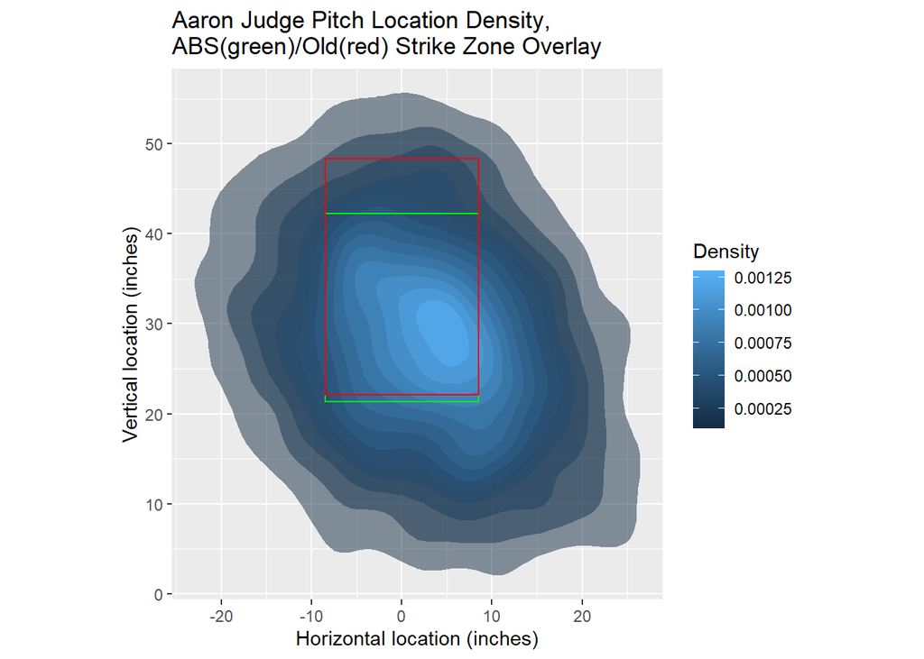

```r
# create global variables for average abs strike zone top and bottom for Judge and Altuve
judge_avg_abs_top <- full_pitch_df %>% filter(batter_name=="Judge, Aaron") %>% summarise(avg_abs_top = mean(abs_sz_top))
judge_avg_abs_bot <- full_pitch_df %>% filter(batter_name=="Judge, Aaron") %>% summarise(avg_abs_bot = mean(abs_sz_bot))
judge_avg_sz_top <- full_pitch_df %>% filter(batter_name=="Judge, Aaron", sz_top!="NA") %>% summarise(avg_sz_top = mean(sz_top))
judge_avg_sz_bot <- full_pitch_df %>% filter(batter_name=="Judge, Aaron", sz_bot!="NA") %>% summarise(avg_sz_bot = mean(sz_bot))

altuve_avg_abs_top <- full_pitch_df %>% filter(batter_name=="Altuve, José") %>% summarise(avg_abs_top = mean(abs_sz_top))
altuve_avg_abs_bot <- full_pitch_df %>% filter(batter_name=="Altuve, José") %>% summarise(avg_abs_bot = mean(abs_sz_bot))
altuve_avg_sz_top <- full_pitch_df %>% filter(batter_name=="Altuve, José") %>% summarise(avg_sz_top = mean(sz_top))
altuve_avg_sz_bot <- full_pitch_df %>% filter(batter_name=="Altuve, José") %>% summarise(avg_sz_bot = mean(sz_bot))

# graph density of pitch locations for Judge and Altuve with overlaid abs strike zone and regular strike zone

judge_pitch_loc_plot <- ggplot(full_pitch_df %>% filter(batter_name=="Judge, Aaron"), aes(x = plate_x, y = plate_z)) +
  stat_density2d(
    aes(fill = after_stat(level)),
    geom = "polygon",
    alpha = 0.5
  ) +
  scale_fill_continuous(name = "Density") +  geom_rect(
    xmin = -8.5, xmax = 8.5,
    ymin = judge_avg_abs_bot$avg_abs_bot, ymax = judge_avg_abs_top$avg_abs_top,
    fill = NA, color = "green",
    inherit.aes = FALSE
  ) +
  geom_rect(
    xmin = -8.5, xmax = 8.5,
    ymin = judge_avg_sz_bot$avg_sz_bot, ymax = judge_avg_sz_top$avg_sz_top,
    fill = NA, color = "red",
    inherit.aes = FALSE
  ) +
  coord_fixed() +
  labs(title = "Aaron Judge Pitch Location Density, \nABS(green)/Old(red) Strike Zone Overlay", x = "Horizontal location (inches)", y = "Vertical location (inches)")

altuve_pitch_loc_plot <- ggplot(full_pitch_df %>% filter(batter_name=="Altuve, José"), aes(x = plate_x, y = plate_z)) +
  stat_density2d(
    aes(fill = after_stat(level)),
    geom = "polygon",
    alpha = 0.5
  ) +
  scale_fill_continuous(name = "Density") +  geom_rect(
    xmin = -8.5, xmax = 8.5,
    ymin = altuve_avg_abs_bot$avg_abs_bot, ymax = altuve_avg_abs_top$avg_abs_top,
    fill = NA, color = "green",
    inherit.aes = FALSE
  ) +
  geom_rect(
    xmin = -8.5, xmax = 8.5,
    ymin = altuve_avg_sz_bot$avg_sz_bot, ymax = altuve_avg_sz_top$avg_sz_top,
    fill = NA, color = "red",
    inherit.aes = FALSE
  ) +
  coord_fixed() +
  labs(title = "José Altuve Pitch Location Density, \nABS(green)/Old(red) Strike Zone Overlay", x = "Horizontal location (inches)", y = "Vertical location (inches)")

judge_pitch_loc_plot
```

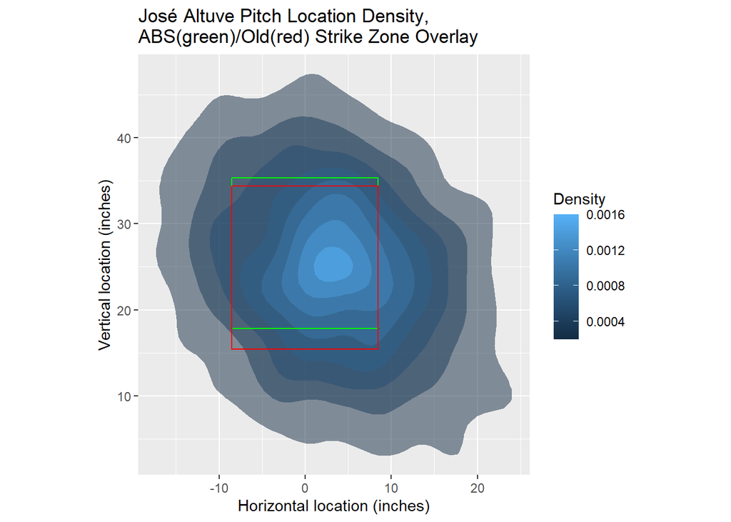

```r
altuve_pitch_loc_plot
```

What number of pitches in the old strike zone will now be outside of the new strike zone for each player?

```r
full_pitch_df %>% filter(batter_name=="Judge, Aaron" & old_sz_biz == 1 & abs_sz_biz == 0) %>% nrow()
```

```
## [1] 121
```

```r
full_pitch_df %>% filter(batter_name=="Altuve, José" & old_sz_biz == 1 & abs_sz_biz == 0) %>% nrow()
```

```
## [1] 73
```

So 121 pitches that were in Judge’s old strike zone are now outside of the new strike zone, while only 73 pitches that were in Altuve’s old strike zone are now outside of the new strike zone. What happened on those pitches?

```r
full_pitch_df %>% filter(batter_name=="Judge, Aaron" & old_sz_biz == 1 & abs_sz_biz == 0) %>% group_by(description) %>% summarise(Outcome = n()) %>% arrange(desc(Outcome))
```

```
## # A tibble: 6 × 2
##   description     Outcome
##   <chr>             <int>
## 1 foul                 33
## 2 swinging_strike      31
## 3 ball                 25
## 4 hit_into_play        15
## 5 called_strike        14
## 6 foul_tip              3
```

```r
full_pitch_df %>% filter(batter_name=="Judge, Aaron" & old_sz_biz == 1 & abs_sz_biz == 0 & description == "hit_into_play") %>% group_by(events) %>% summarise(Outcome = n()) %>% arrange(desc(Outcome))
```

```
## # A tibble: 5 × 2
##   events    Outcome
##   <chr>       <int>
## 1 field_out      11
## 2 double          1
## 3 home_run        1
## 4 sac_fly         1
## 5 single          1
```

```r
full_pitch_df %>% filter(batter_name=="Altuve, José" & old_sz_biz == 1 & abs_sz_biz == 0) %>% group_by(description) %>% summarise(Outcome = n()) %>% arrange(desc(Outcome))
```

```
## # A tibble: 6 × 2
##   description     Outcome
##   <chr>             <int>
## 1 hit_into_play        27
## 2 called_strike        15
## 3 foul                 12
## 4 ball                 10
## 5 swinging_strike       8
## 6 foul_bunt             1
```

```r
full_pitch_df %>% filter(batter_name=="Altuve, José" & old_sz_biz == 1 & abs_sz_biz == 0 & description == "hit_into_play") %>% group_by(events) %>% summarise(Outcome = n()) %>% arrange(desc(Outcome))
```

```
## # A tibble: 6 × 2
##   events                    Outcome
##   <chr>                       <int>
## 1 field_out                      16
## 2 single                          5
## 3 double                          2
## 4 fielders_choice                 2
## 5 grounded_into_double_play       1
## 6 home_run                        1
```

So, for Judge, the most common outcome of pitches that were in his old strike zone but are now outside of the new strike zone is a foul ball. For Altuve, the most common outcome is a batted ball. On pitches put in play that meet the above criteria, Judge was a worse hitter than Altuve (.214AVG vs .296AVG, respectively). With the change in strike zone, Judge would have to swing less at pitches that are now outside of the new strike zone, while Altuve *could* swing at those pitches if he hits them well, but then the change would be less impactful for him.

Which teams had the best and worst [wOBA](https://www.lookoutlanding.com/2017/3/7/14783982/an-idiots-guide-to-advanced-statistics-woba-and-wrc-sabermetrics) on pitches in the old strike zone that would not be in the new strike zone?

```r
# filter for pitches in old strike zone but not in new strike zone, group by team, and calculate batting average
full_pitch_df %>% filter(old_sz_biz == 1 & abs_sz_biz == 0 & description == "hit_into_play" & estimated_woba_using_speedangle!="NA") %>% group_by(batting_team) %>% summarise(team_est_wOBA = mean(estimated_woba_using_speedangle), n=n()) %>% arrange(desc(team_est_wOBA))
```

```
## # A tibble: 30 × 3
##    batting_team team_est_wOBA     n
##    <chr>                <dbl> <int>
##  1 PHI                  0.401   170
##  2 ATL                  0.394   142
##  3 PIT                  0.382   143
##  4 MIL                  0.380   136
##  5 COL                  0.363    95
##  6 SD                   0.358   162
##  7 DET                  0.356   101
##  8 BOS                  0.352   157
##  9 CLE                  0.343   164
## 10 MIA                  0.342   156
## # ℹ 20 more rows
```

Interpretation of above could be: teams that have the highest wOBA on pitches that are now outside of the new strike zone (COL, MIL, PIT, ATL, PHI) are going to see less benefit from the new strike zone. Teams that have the lowest wOBA on pitches that are now outside of the new strike zone (LAD, CHC, CWS, TB, MIN) are going to see more benefit from the new strike zone.

One question raised during this period of EDA was "how will the change in strike zone size affect players?" This broad question lends itself to a myriad of further investigation. To focus on identifying important questions to research, we brainstormed who the stakeholders in such a project would be. Players who could benefit from the change in strike zone size would be the most interested in the results of this analysis. Players who could suffer from the change in strike zone size would also be interested in the results. Managers and front offices would be interested in the results to determine how to adjust their strategies for the upcoming season. Fans would be interested in the results to see how their favorite players might be affected by the change in strike zone size.

The more fine grained questions about specific players' mechanics is too narrow a scope for the general body of stakeholders. However, the question of "who will benefit the most?" and "who will suffer the most?" is a good starting point for further research.

The next steps will be to determine which metrics and interpretations of our EDA will be most useful for answering these questions. This will be done through a "research conversation" with the sabermetrics community. Reading similar analyses, such as those done by Fangraphs, Baseball Prospectus, and other baseball analytics websites, will be helpful in determining the best approach to answering these questions.

Below is some pseudocode for possible deliverables for this project:

## Research Objectives:

### Who will benefit the most? Who will suffer the most?

#### Calculating strikezone differences for 2024:

```
Start

  Mutate and create % strikezone diff

    Calculate average height x width for recorded strikezone and compare % area difference to ABS strikezone.  (done)

  Mutate and create batting average on balls in zone (BABIZ) for old and new zones

    Filter for pitches located in each zone, respectively, and calculate average

  Repeat for interesting stats

    wOBA/BABIPIZ (Batting Average on Balls in play pitched in the zone/... (started above)

  Compare players who benefit vs suffer

    Group_by, sort

End
```

#### Long-term: model player performances for 2024 if strikezone was ABS size:

```
Start

  Create distance from  strikezone metric

    ball_loc-nearest strikezone edge

  Train model on distance from strikezone edge, count, more etc

    Start with metrics like BA, can model other stats as well, ~ distance_from_zone, count, pitch velo, pitch break, etc

  Mutate predicted field to be NA for each pitch that is on the line between old and new zone

    filter for pitch location in ABS-Zone distance away from zone, make NA

  Predict outcome for those limbo-state pitches with new strike zone

  Make sure model is trained so if a batter would swing at a pitch on the edge of old zone, their habits stay true (and same if not swinging)

  Calculate difference in WAR, other key metrics for players. Who performed better? Worse?

End
```

Petti, Bill, and Saiem Gilani. n.d. “Baseballr: Acquiring and Analyzing Baseball Data.” https://github.com/BillPetti/baseballr.